# Data Analysis

```r
summary(Dino_Gamma_model) # significance in both the 25 and 30 degree treatment
```

```
## Family:  c("GA", "Gamma")
##
## Call:  gamlss(formula = Dino_Density ~ Date * Treatment +
##     random(Species_ID) + random(Field_Site) + random(Acclimation_Period),
##     family = GA(), data = Dino_Symbionts, control = gamlss.control(n.cyc = 3))
##
##
## Fitting method: RS()
##
## ------------------------------------------------------------------
## Mu link function:  log
## Mu Coefficients:
##                             Estimate Std. Error t value Pr(>|t|)
## (Intercept)                  8.06079    0.25027  32.208  < 2e-16 ***
## Date11/9/2021               -0.16934    0.34106  -0.496  0.62449
## Date11/13/2021              -0.23477    0.35394  -0.663  0.51405
## Treatment25C                -1.32556    0.39574  -3.350  0.00291 **
## Treatment30C                -0.74465    0.32308  -2.305  0.03104 *
## Date11/9/2021:Treatment25C   0.43494    0.55161   0.788  0.43886
## Date11/13/2021:Treatment25C  1.03874    0.54261   1.914  0.06874 .
## Date11/9/2021:Treatment30C  -0.23333    0.46976  -0.497  0.62435
## Date11/13/2021:Treatment30C  0.03936    0.46977   0.084  0.93399
## ---
## Signif. codes:  0 '***' 0.001 '**' 0.01 '*' 0.05 '.' 0.1 ' ' 1
##
## ------------------------------------------------------------------
## Sigma link function:  log
## Sigma Coefficients:
##             Estimate Std. Error t value Pr(>|t|)
## (Intercept) -0.48968    0.09084   -5.39 2.09e-05 ***
## ---
## Signif. codes:  0 '***' 0.001 '**' 0.01 '*' 0.05 '.' 0.1 ' ' 1
##
## ------------------------------------------------------------------
## NOTE: Additive smoothing terms exist in the formulas:
##  i) Std. Error for smoothers are for the linear effect only.
## ii) Std. Error for the linear terms maybe are not accurate.
## ------------------------------------------------------------------
## No. of observations in the fit:  54
## Degrees of Freedom for the fit:  32.10774
##       Residual Deg. of Freedom:  21.89226
##                       at cycle:  3
##
## Global Deviance:     908.8819
##             AIC:     973.0974
##             SBC:     1036.959
```

**Table 1**: ZC symbiont density, using gamlss with Weibull distribution. Significance compared to pre-heat of control.

[output not shown]

**Table 2**: ZX symbiont density, using gamlss with Gamma distribution. Significance compared to pre-heat of control.

[output not shown]

**Dunn and Kruskal Wallis Test on Density Data:** Used for box blot

```r
kruskal.test(Green_Density ~ Treatment, data = Green_Symbionts) # p = 0.004
```

```
##
##  Kruskal-Wallis rank sum test
##
## data:  Green_Density by Treatment
## Kruskal-Wallis chi-squared = 11.091, df = 2, p-value = 0.003905
```

```r
dunnTest(Green_Density ~ Treatment, data = Green_Symbionts)
```

```
## Dunn (1964) Kruskal-Wallis multiple comparison
```

```
##   p-values adjusted with the Holm method.
```

```
##      Comparison          Z     P.unadj       P.adj
## 1     25C - 30C -2.5463792 0.010884689 0.021769378
## 2 25C - Control  0.1437093 0.885729997 0.885729997
## 3 30C - Control  3.0094276 0.002617404 0.007852213
```

```r
# sig. difference between 25-30 and between 30-control

kruskal.test(Dino_Density ~ Treatment, data = Dino_Symbionts) # not significant
```

```
##
##  Kruskal-Wallis rank sum test
##
## data:  Dino_Density by Treatment
## Kruskal-Wallis chi-squared = 4.742, df = 2, p-value = 0.09339
```

```r
dunnTest(Dino_Density ~ Treatment, data = Dino_Symbionts) # not significant
```

```
## Dunn (1964) Kruskal-Wallis multiple comparison
##   p-values adjusted with the Holm method.
```

```
##      Comparison          Z    P.unadj     P.adj
## 1     25C - 30C  0.3672174 0.71345689 0.7134569
## 2 25C - Control -1.4749869 0.14021607 0.2804321
## 3 30C - Control -2.1053369 0.03526199 0.1057860
```

**Plots for symbiont data:** Box plot with event on the x axis and logged symbiont density on the y axis, separated by treatment.

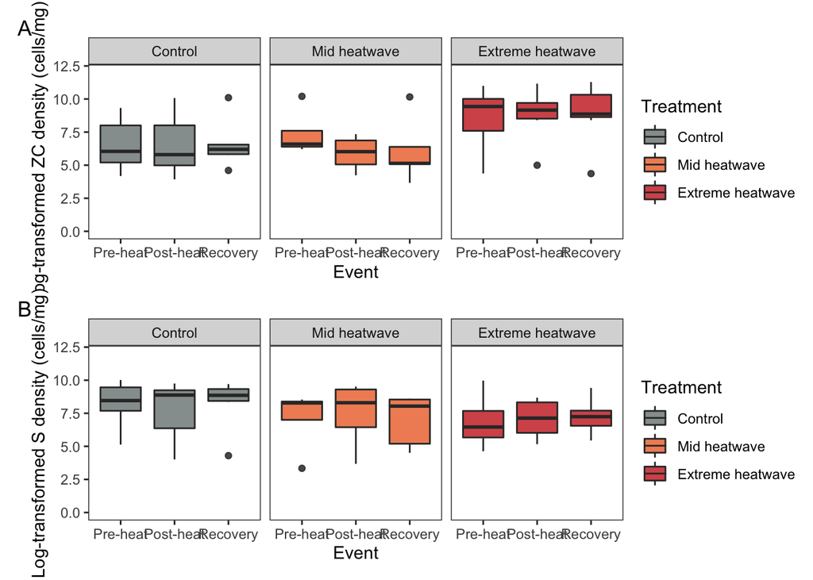

```r
treatment_labels = c("Control", "Mid heatwave", "Extreme heatwave")
names(treatment_labels) = (c("Control", "25C", "30C"))
green_plot <- ggplot(Green_Symbionts, aes(x = Date, y = log(Green_Density),
                                          fill = Treatment)) +
  geom_boxplot(alpha = 0.85) +
  xlab("Event") +
  ylab("Log-transformed ZC density (cells/mg)") +
  facet_grid(. ~ Treatment,
             labeller = labeller(Treatment = treatment_labels)) +
  scale_fill_manual(limits = c("Control", "25C", "30C"),
                    labels = c("Control", "Mid heatwave", "Extreme heatwave"),
                    values = cols_for_heat) +
  theme_test()

green_plot <- green_plot + ylim(0,12) +
  scale_x_discrete(labels=c("11/5/2021" = "Pre-heat", "11/9/2021" = "Post-heat",
                            "11/13/2021" = "Recovery"))

dino_plot <- ggplot(Dino_Symbionts, aes(x = Date, y = log(Dino_Density),
                                        fill = Treatment)) +
  geom_boxplot(alpha = 0.85) +
  xlab("Event") +
  ylab("Log-transformed S density (cells/mg)") +
  facet_grid(. ~ Treatment,
             labeller = labeller(Treatment = treatment_labels)) +
  scale_fill_manual(limits = c("Control", "25C", "30C"),
                    labels = c("Control", "Mid heatwave", "Extreme heatwave"),
                    values = cols_for_heat) +
  theme_test()
dino_plot <- dino_plot + ylim(0,12) +
  scale_x_discrete(labels=c("11/5/2021" = "Pre-heat", "11/9/2021" = "Post-heat",
                            "11/13/2021" = "Recovery"))

density_plot = (green_plot + dino_plot) + plot_layout(ncol=1)
density_plot <- density_plot + plot_annotation(tag_levels = 'A')
density_plot
```

```r
ggsave(here("./images/density_plot.png"), density_plot, width = 10, height = 9)
```

#### Mitotic Index Data

MI is the amount of cell division in the symbionts, calculated as a %.

```r
# Organizing the data
MI_Data <- health_data %>%
  select(-c(Event, Base_Width, Base_Length, Base_Diagonal, Base_Diameter_mm,
            Nb_Tentacles, Weight_Total_g, Weight_Tube_g, Weight_Tentacle_g,
            Green_Cells, Dino_Cells, Feeding_Time_Min, Feeding_Time, Feeding_Start,
            Feeding_Stop, Photo_ID, Removed, Fv_Fm_1, Fv_Fm_2, Fv_Fm_3, PAM_avg,
            Event_True)) %>%
  filter(Date == "11/5/2021" | Date == "11/9/2021" | Date == "11/13/2021") %>%
  mutate(Date = fct_relevel(Date, "11/5/2021", "11/9/2021", "11/13/2021")) %>%
  drop_na(Green_Density) %>%
  drop_na(Dino_Density) %>%
  drop_na(MI_Green) %>%
  drop_na(MI_Dino) %>%
  mutate(Acclimation_Period = as.factor(Acclimation_Period)) %>%
  mutate(MI_Dino_scaled = MI_Dino + 0.01) %>%
  mutate(MI_Green_scaled = MI_Green + 0.01)
```

**Checking Normality and Equal Variance:**

```r
#Green
shapiro.test(MI_Data$Green_Density)
```

```
##
##  Shapiro-Wilk normality test
##
## data:  MI_Data$Green_Density
## W = 0.64647, p-value = 3.82e-10
```

```r
bartlett.test(Green_Density ~ Treatment, MI_Data)
```

```
##
##  Bartlett test of homogeneity of variances
##
## data:  Green_Density by Treatment
## Bartlett's K-squared = 23.091, df = 2, p-value = 9.681e-06
```

```r
#Dino
shapiro.test(MI_Data$Dino_Density)
```

```
##
##  Shapiro-Wilk normality test
##
## data:  MI_Data$Dino_Density
## W = 0.80442, p-value = 5.198e-07
```

```r
bartlett.test(Dino_Density ~ Treatment, MI_Data) # p-value = 0.1483
```

```
##
##  Bartlett test of homogeneity of variances
##
## data:  Dino_Density by Treatment
## Bartlett's K-squared = 3.8169, df = 2, p-value = 0.1483
```

ZC (green) symbiont density does not meet assumptions of normality or equal variance, while ZC (dino) does not meet assumption of normality but meets the assumption of equal variance. We will run Dunn and Kruskal Wallis tests on the MI data to test for significant differences.

**Dunn and Kruskal Wallis Test on MI Data:**

```r
kruskal.test(MI_Green ~ Treatment, data = MI_Data) # p = 0.009
```

```
##
##  Kruskal-Wallis rank sum test
##
## data:  MI_Green by Treatment
## Kruskal-Wallis chi-squared = 9.492, df = 2, p-value = 0.008686
```

```r
dunnTest(MI_Green ~ Treatment, data = MI_Data) # sig. difference between 25-30
```

```
## Dunn (1964) Kruskal-Wallis multiple comparison
```

```
##   p-values adjusted with the Holm method.
```

```
##      Comparison         Z     P.unadj       P.adj
## 1     25C - 30C -3.036394 0.002394262 0.007182786
## 2 25C - Control -1.441840 0.149347449 0.149347449
## 3 30C - Control  1.734539 0.082822412 0.165644824
```

```r
kruskal.test(MI_Dino ~ Treatment, data = MI_Data) # not significant
```

```
##
##  Kruskal-Wallis rank sum test
##
## data:  MI_Dino by Treatment
## Kruskal-Wallis chi-squared = 0.51372, df = 2, p-value = 0.7735
```

```r
dunnTest(MI_Dino ~ Treatment, data = MI_Data) # not significant
```

```
## Dunn (1964) Kruskal-Wallis multiple comparison
##   p-values adjusted with the Holm method.
```

```
##      Comparison           Z   P.unadj     P.adj
## 1     25C - 30C -0.07275603 0.9420003 0.9420003
## 2 25C - Control -0.60896106 0.5425503 1.0000000
## 3 30C - Control -0.61859436 0.5361836 1.0000000
```

**Plot for MI data:** Box plot with event on the x axis and mitotic index on the y axis, separated by treatment.

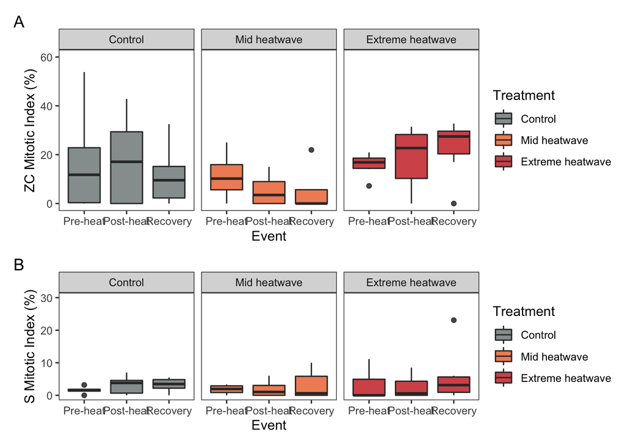

```r
green_MI_plot <- ggplot(Green_Symbionts, aes(x = Date, y = MI_Green,
                                             fill = Treatment)) +
  geom_boxplot(alpha = 0.85) +
  xlab("Event") +
  ylab("ZC Mitotic Index (%)") +
  facet_grid(. ~ Treatment,
             labeller = labeller(Treatment = treatment_labels)) +
  scale_fill_manual(limits = c("Control", "25C", "30C"),
                    labels = c("Control", "Mid heatwave", "Extreme heatwave"),
                    values = cols_for_heat) +
  theme_test()
green_MI_plot <- green_MI_plot + ylim(0,60) +
  scale_x_discrete(labels=c("11/5/2021" = "Pre-heat", "11/9/2021" = "Post-heat",
                            "11/13/2021" = "Recovery"))

dino_MI_plot <- ggplot(Dino_Symbionts, aes(x = Date, y = MI_Dino,
                                           fill = Treatment)) +
  geom_boxplot(alpha = 0.85) +
  xlab("Event") +
  ylab("S Mitotic Index (%)") +
  facet_grid(. ~ Treatment,
             labeller = labeller(Treatment = treatment_labels)) +
  scale_fill_manual(limits = c("Control", "25C", "30C"),
                    labels = c("Control", "Mid heatwave", "Extreme heatwave"),
                    values = cols_for_heat) +
  theme_test()
dino_MI_plot <- dino_MI_plot + ylim(0,30) +
  scale_x_discrete(labels=c("11/5/2021" = "Pre-heat", "11/9/2021" = "Post-heat",
                            "11/13/2021" = "Recovery"))

MI_plot = (green_MI_plot + dino_MI_plot) + plot_layout(ncol=1, heights=c(1.5,1))
MI_plot <- MI_plot + plot_annotation(tag_levels = 'A')
MI_plot
```

```r
ggsave(here("./images/MI_plot.png"), MI_plot, width = 10, height = 9)
```

### PAM data

We filter out aposymbiotic anemones.

```r
# Organizing the data adding average and standard error Fv/Fm
PAM_individuals <- health_data %>%
  filter(Green_Density > 1000 | Dino_Density > 1000) %>%
  distinct(Species_ID)

PAM_data <- health_data %>%
  select(-c(Base_Width, Base_Length, Base_Diagonal, Base_Diameter_mm, Nb_Tentacles,
            Weight_Total_g, Weight_Tube_g, Weight_Tentacle_g, Green_Cells, Dino_Cells,
            Feeding_Time_Min, Feeding_Time, Feeding_Start, Feeding_Stop, Photo_ID,
            Removed, Div_Green, Div_Dino, MI_Green, MI_Dino, Acclimation_Period,
            Green_Density, Dino_Density)) %>%
  drop_na(Time_Point) %>%
  drop_na(PAM_avg) %>%
  group_by(Treatment, Date) %>%
  mutate(Mean_PAM = mean(PAM_avg), SE_PAM = std.error(PAM_avg))

filtered_PAM_data = PAM_individuals %>%
  left_join(PAM_data) %>%
  filter(Date == "11/6/2021" | Date == "11/9/2021" | Date == "11/13/2021") %>%
  filter(Time_Point != 4) %>%
  mutate(Date = fct_relevel(Date, "11/6/2021", "11/9/2021", "11/13/2021"))
```

**Checking Normality and Equal Variance:**

```r
shapiro.test(filtered_PAM_data$PAM_avg)
```

```
##
##  Shapiro-Wilk normality test
##
## data:  filtered_PAM_data$PAM_avg
## W = 0.84753, p-value = 3.465e-08
```

```r
bartlett.test(PAM_avg ~ Treatment, data = filtered_PAM_data)
```

```
##
##  Bartlett test of homogeneity of variances
##
## data:  PAM_avg by Treatment
## Bartlett's K-squared = 21.408, df = 2, p-value = 2.245e-05
```

Our data does not meet the assumptions of normality and equal variance (p < 0.05) and therefore we will use Dunn and Kruskal Wallis tests to test for significant differences.

```r
kruskal.test(PAM_avg ~ Treatment, data = filtered_PAM_data) # significance
```

```
##
##  Kruskal-Wallis rank sum test
##
## data:  PAM_avg by Treatment
## Kruskal-Wallis chi-squared = 8.0406, df = 2, p-value = 0.01795
```

```r
dunnTest(PAM_avg ~ Treatment, data = filtered_PAM_data)
```

```
##      Comparison          Z     P.unadj      P.adj
## 1     25C - 30C -2.6353649 0.008404688 0.02521406
## 2 25C - Control -0.6723531 0.501358906 0.50135891
## 3 30C - Control  2.1391425 0.032424133 0.06484827
```

```r
# significance only between 25 and 30
```

**Plot for PAM:** Line plot with event on the x axis and average (+/- standard error) PAM measurements on the y axis, colour indicate treatments.

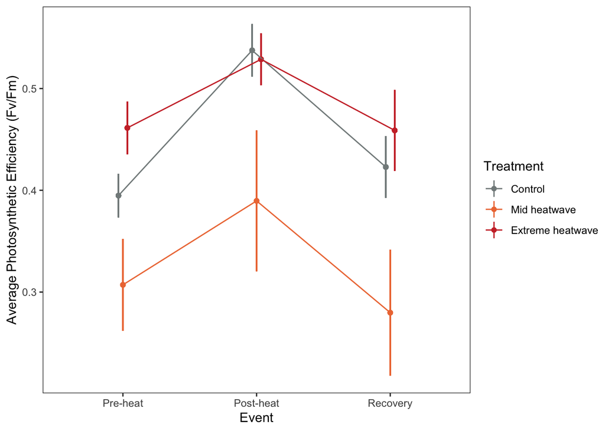

```r
PAM_over_time <- ggplot(data = filtered_PAM_data, aes(x=Date, y = Mean_PAM,
                                                      colour = Treatment,
                                                      group = Treatment)) +
  geom_point(position = position_dodge(width = 0.1)) +
  geom_linerange(aes(ymin = Mean_PAM - SE_PAM,
                     ymax = Mean_PAM + SE_PAM), position = position_dodge(width = 0.1)) +
  geom_line(position = position_dodge(width = 0.1)) +
  labs(x="Event",
       y = "Average Photosynthetic Efficiency (Fv/Fm)") +
  scale_colour_manual(limits = c("Control", "25C", "30C"),
                    labels = c("Control", "Mid heatwave", "Extreme heatwave"),
                    values = cols_for_heat) +
  theme_test()
PAM_over_time <- PAM_over_time +
  scale_x_discrete(labels=c("11/6/2021" = "Pre-heat", "11/9/2021" = "Post-heat",
                            "11/13/2021" = "Recovery"))
PAM_over_time
```

```r
ggsave(here("./images/PAM_over_time.png"), PAM_over_time)
```

### Size Data

Measuring the size of the base as a proxy for weight.

```r
# Organizing the data and adding average and standard error of base size
Size_Data <- health_data %>%
  select(-c(Base_Width, Base_Length, Base_Diagonal, Nb_Tentacles, Weight_Total_g,
            Weight_Tube_g, Weight_Tentacle_g, Weight_Tentacle_mg, Green_Cells,
            Dino_Cells, Feeding_Time_Min, Feeding_Time, Feeding_Start, Feeding_Stop,
            Photo_ID, Removed, Fv_Fm_1, Fv_Fm_2, Fv_Fm_3, PAM_avg, Green_Density,
            Dino_Density, MI_Green, MI_Dino, Div_Green, Div_Dino)) %>%
  filter(Date == "11/5/2021" | Date == "11/9/2021" | Date == "11/13/2021") %>%
  mutate(Date = fct_relevel(Date, "11/5/2021", "11/9/2021", "11/13/2021"),
        (Treatment = fct_relevel(Treatment, "Control", "25C", "30C"))) %>%
  drop_na(Base_Diameter_mm) %>%
  mutate(Acclimation_Period = as.factor(Acclimation_Period)) %>%
  group_by(Treatment, Date) %>%
  mutate(Mean_Size = mean(Base_Diameter_mm), SE_Size = std.error(Base_Diameter_mm))
```

**Checking for Normality and Equal Variance:**

```r
shapiro.test(Size_Data$Base_Diameter_mm)
```

```
##
##  Shapiro-Wilk normality test
##
## data:  Size_Data$Base_Diameter_mm
## W = 0.94517, p-value = 0.0002429
```

```r
bartlett.test(Base_Diameter_mm ~ Treatment, data = Size_Data)
```

```
##
##  Bartlett test of homogeneity of variances
##
## data:  Base_Diameter_mm by Treatment
## Bartlett's K-squared = 3.8061, df = 2, p-value = 0.1491
```

The distributions do not meet assumptions of normality but does meet the assumption of equal variance.

**Checking Distributions of Symbiont Data:** Determining if the data fits other distributions.

```r
exp_test(Size_Data$Base_Diameter_mm)            #p-value < 0.05
```

```
##
##  Test for exponentiality based on a transformation to uniformity
##
## data:  Size_Data$Base_Diameter_mm
## T = -11.277, p-value < 2.2e-16
```

```r
gamma_test(Size_Data$Base_Diameter_mm)          #p = 0.1874
```

```
##
##  Test of fit for the Gamma distribution
##
## data:  Size_Data$Base_Diameter_mm
## V = 1.8642, p-value = 0.1874
```

```r
lnorm_test(Size_Data$Base_Diameter_mm)          #p = 0.4117
```

```
##
##  Test for the lognormal distribution based on a transformation to
##  normality
##
## data:  Size_Data$Base_Diameter_mm
## p-value = 0.4117
```

```r
normal_test(Size_Data$Base_Diameter_mm)         #p-value < 0.05
```

```
##
##  Correlation test for normality
##
## data:  Size_Data$Base_Diameter_mm
## R = 0.98889, p-value = 0.001424
## alternative hypothesis: Size_Data$Base_Diameter_mm does not follow a normal distribution.
```

```r
weibull_test(Size_Data$Base_Diameter_mm)        #p-value < 0.05
```

```
##
##  Test for the Weibull distribution
##
## data:  Size_Data$Base_Diameter_mm
## p-value < 2.2e-16
```

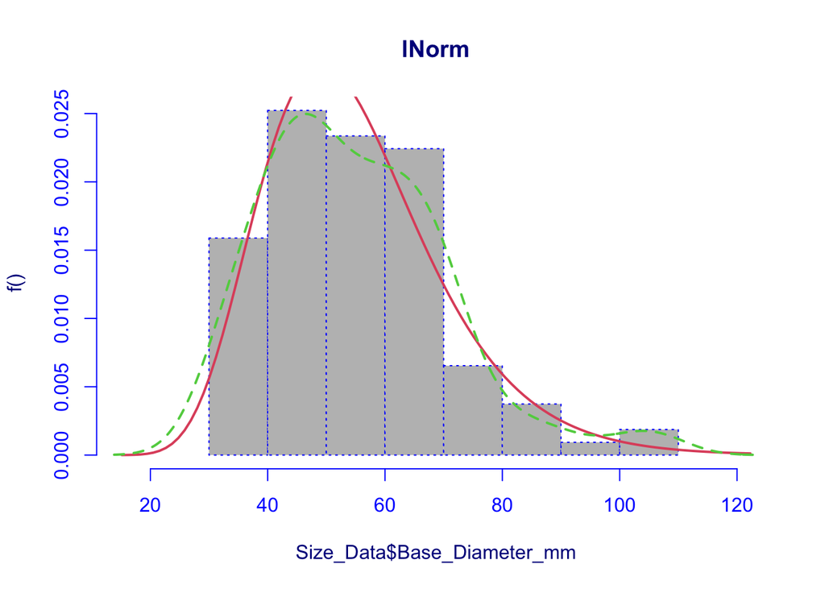

```r
# Run lnorm since it has the higest p value
Size_lnorm <- histDist(Size_Data$Base_Diameter_mm, "LOGNO", density = T, main = "lNorm")

# Choosing the best distribution by comparing AIC values
Size_lnorm <- histDist(Size_Data$Base_Diameter_mm, "LOGNO", density = T, main = "lNorm")
```

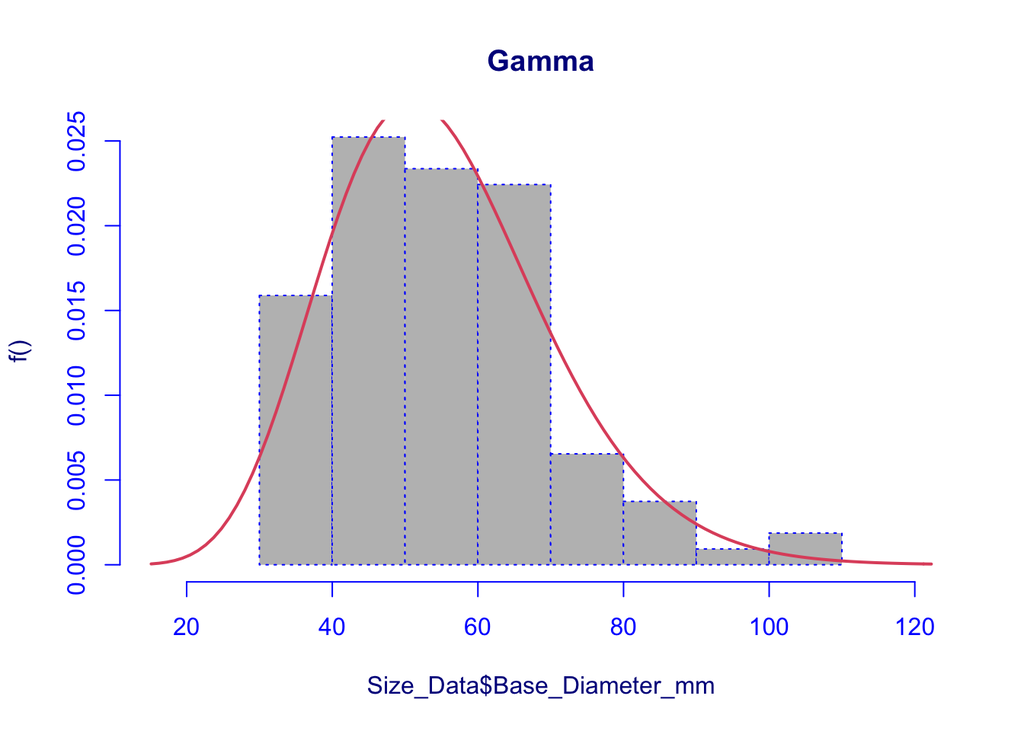

```r
#AIC = 880.625
Feeding_Gamma <- histDist(Size_Data$Base_Diameter_mm, "GA", density = F, main = "Gamma")
```

```r
#AIC = 883.161
```

**Running Models:** We are going to run a lNorm model on our size data because the p value is larger and AIC value is smaller.

```r
Size_Data$orderTreatment = ordered(Size_Data$Treatment, levels = c("Control", "25C", "30C"))

Size_lNorm_model <- gamlss(formula = Base_Diameter_mm ~ Date*Treatment +
                             random(Species_ID) + random(Field_Site) +
                             random(Acclimation_Period),
                           family = LOGNO(), data = Size_Data,
                           control = gamlss.control(n.cyc = 4))
```

```
## GAMLSS-RS iteration 1: Global Deviance = 566.2608
## GAMLSS-RS iteration 2: Global Deviance = 566.254
## GAMLSS-RS iteration 3: Global Deviance = 566.2585
## GAMLSS-RS iteration 4: Global Deviance = 566.2585
```

```r
 summary(Size_lNorm_model) # significant in 30
```

```
## Family:  c("LOGNO", "Log Normal")
##
## Call:  gamlss(formula = Base_Diameter_mm ~ Date * Treatment +
##     random(Species_ID) + random(Field_Site) + random(Acclimation_Period),
##     family = LOGNO(), data = Size_Data, control = gamlss.control(n.cyc = 4))
##
## Fitting method: RS()
##
## ------------------------------------------------------------------
## Mu link function:  identity
## Mu Coefficients:
##                              Estimate Std. Error t value Pr(>|t|)
## (Intercept)                  3.891115   0.019396 200.618  < 2e-16 ***
## Date11/9/2021                0.034371   0.026852   1.280 0.205309
## Date11/13/2021               0.093877   0.026852   3.496 0.000878 ***
## Treatment25C                 0.039133   0.026852   1.457 0.150054
## Treatment30C                 0.109203   0.026852   4.067 0.000137 ***
## Date11/9/2021:Treatment25C   0.038217   0.037560   1.018 0.312859
## Date11/13/2021:Treatment25C -0.092427   0.037560  -2.461 0.016657 *
## Date11/9/2021:Treatment30C  -0.004105   0.037560  -0.109 0.913320
## Date11/13/2021:Treatment30C -0.055277   0.037560  -1.472 0.146148
## ---
## Signif. codes:  0 '***' 0.001 '**' 0.01 '*' 0.05 '.' 0.1 ' ' 1
##
## ------------------------------------------------------------------
## Sigma link function:  log
## Sigma Coefficients:
##             Estimate Std. Error t value Pr(>|t|)
## (Intercept) -2.74376    0.06836  -40.14   <2e-16 ***
## ---
## Signif. codes:  0 '***' 0.001 '**' 0.01 '*' 0.05 '.' 0.1 ' ' 1
##
## ------------------------------------------------------------------
## NOTE: Additive smoothing terms exist in the formulas:
##  i) Std. Error for smoothers are for the linear effect only.
## ii) Std. Error for the linear terms maybe are not accurate.
## ------------------------------------------------------------------
## No. of observations in the fit:  107
## Degrees of Freedom for the fit:  44.92919
##       Residual Deg. of Freedom:  62.07081
##                       at cycle:  4
##
## Global Deviance:     566.2585
##             AIC:     656.1169
##             SBC:     776.2049
```

**Table 3**: Size data, using gamlss with Log Normal distribution. Significance compared to pre-heat of control.

[output not shown]

**Plot for Size:** Line plot with event on the x axis and average (+/- standard error) base size measurements on the y axis, colour indicate treatments.

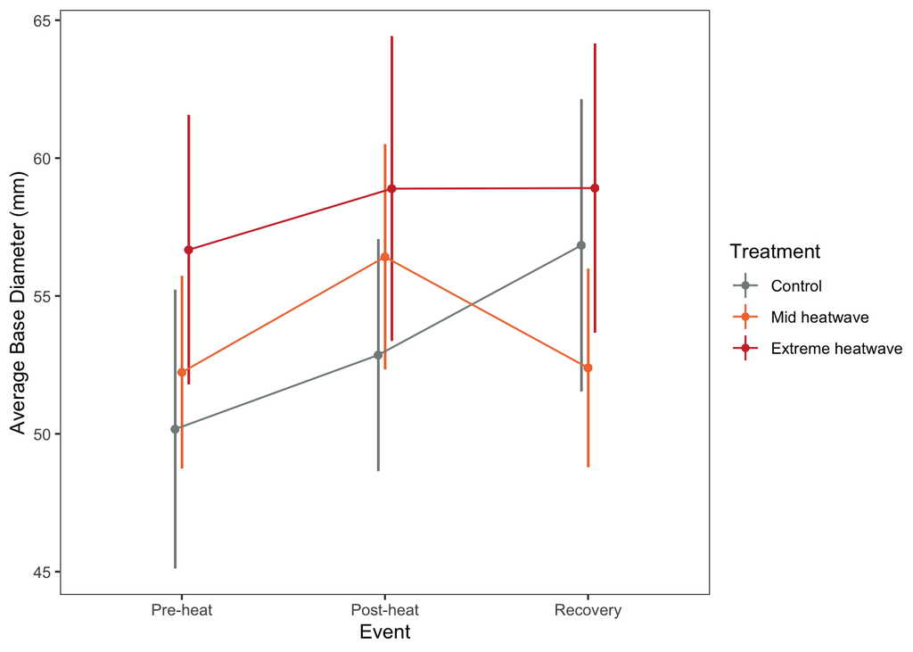

```r
size_plot <- ggplot(data = Size_Data, aes(x=Date, y = Mean_Size,
                                          colour = Treatment, group = Treatment)) +
  geom_point(position = position_dodge(width = 0.1)) +
  geom_linerange(aes(ymin = Mean_Size - SE_Size, ymax = Mean_Size + SE_Size),
                 position = position_dodge(width = 0.1)) +
  geom_line(position = position_dodge(width = 0.1)) +
  labs(x="Event",
       y = "Average Base Diameter (mm)") +
  scale_colour_manual(limits = c("Control", "25C", "30C"),
                    labels = c("Control", "Mid heatwave", "Extreme heatwave"),
                    values = cols_for_heat) +
  theme_test()

size_plot <- size_plot +
  scale_x_discrete(labels=c("11/5/2021" = "Pre-heat", "11/9/2021" = "Post-heat",
                            "11/13/2021" = "Recovery"))
size_plot
```

```r
ggsave(here("./images/size_plot.png"), size_plot)
```